# Final_Results

### Problem and Requirement Description:

#### The task is to analyze the clinical and financial data of patients hospitalized for a certain condition. Some variable names and patient_id's have been anonymized in this dataset. It is required to join the data given in different tables, and find insights about the drivers of cost of care.

### 0. Import packages and csv file

```python
%matplotlib inline
import numpy as np
import pandas as pd
import datetime as DT
import matplotlib.pyplot as plt
import matplotlib.dates as dates
from pandas import *
from operator import itemgetter
import seaborn as sns
import scipy as sp
import scipy.stats
import statsmodels.stats.api as sms
import statsmodels.api as sm
from sklearn import linear_model
from sklearn.linear_model import Lasso
from sklearn.linear_model import LassoCV
from sklearn.metrics import r2_score

bill_amount_data = pd.read_csv("~/Desktop/datasciencepositionatholmusk/bill_amount.csv")
bill_id_data = pd.read_csv("~/Desktop/datasciencepositionatholmusk/bill_id.csv")
clinical_data = pd.read_csv("~/Desktop/datasciencepositionatholmusk/clinical_data.csv")
clinical_data = clinical_data.rename(columns={'id':'patient_id'})
demographics_data = pd.read_csv("~/Desktop/datasciencepositionatholmusk/demographics.csv")
```

## 1. First step: view seperated forms, find basic patterns and join them properly.

### (1).show part of bill_amount data and describe

```python
bill_amount_data.head(3)
```

|  | bill_id | amount |
| --- | --- | --- |
| 0 | 40315104 | 1552.634830 |
| 1 | 2660045161 | 1032.011951 |
| 2 | 1148334643 | 6469.605351 |

```python
bill_amount_data.shape
```

```
(13600, 2)
```

```python
bill_amount_data.describe()
```

|  | bill_id | amount |
| --- | --- | --- |
| count | 1.360000e+04 | 13600.000000 |
| mean | 5.007147e+09 | 5464.767783 |
| std | 2.885919e+09 | 7717.479509 |
| min | 5.584120e+05 | 79.496707 |
| 25% | 2.485853e+09 | 950.689008 |
| 50% | 4.992958e+09 | 1516.951136 |
| 75% | 7.524563e+09 | 7307.056573 |
| max | 9.999633e+09 | 81849.751340 |

### (2). show part of bill_id data and describe

```python
bill_id_data.head(3)
```

|  | bill_id | patient_id | date_of_admission |
| --- | --- | --- | --- |
| 0 | 7968360812 | 1d21f2be18683991eb93d182d6b2d220 | 2011-01-01 |
| 1 | 6180579974 | 62bdca0b95d97e99e1c712048fb9fd09 | 2011-01-01 |
| 2 | 7512568183 | 1d21f2be18683991eb93d182d6b2d220 | 2011-01-01 |

```python
bill_id_data.shape
```

```
(13600, 3)
```

```python
bill_id_data["patient_id"].unique().shape
```

```
(3000,)
```

### The bill_id_data have same rows with the bill_amount_data but different columns. The bill_id_data should be a supplement to the bill_amount_data so they both can be join immediately. But the unique patient_id's number is much less than the bill amounts' number. And from the data_of_admission we can see that each patient had paid their bill amounts more than once in one day.

### (3). show part of clinical_data and describe

```python
clinical_data.head(3)
```

|  | patient_id | date_of_admission | date_of_discharge | medical_history_1 | medical_history_2 | medical_history_3 | medical_history_4 | medical_history_5 | medical_history_6 | medical_history_7 | ... | symptom_1 | symptom_2 | symptom_3 | symptom_4 | symptom_5 | lab_result_1 | lab_result_2 | lab_result_3 | weight | height |
| --- | --- | --- | --- | --- | --- | --- | --- | --- | --- | --- | --- | --- | --- | --- | --- | --- | --- | --- | --- | --- | --- |
| 0 | 1d21f2be18683991eb93d182d6b2d220 | 2011-01-01 | 2011-01-11 | 0 | 1.0 | 0 | 0 | 0.0 | 0 | 0 | ... | 0 | 0 | 0 | 1 | 1 | 13.2 | 30.9 | 123.0 | 71.3 | 161.0 |
| 1 | 62bdca0b95d97e99e1c712048fb9fd09 | 2011-01-01 | 2011-01-11 | 0 | 0.0 | 0 | 0 | 0.0 | 0 | 0 | ... | 0 | 0 | 1 | 1 | 1 | 13.8 | 22.6 | 89.0 | 78.4 | 160.0 |
| 2 | c85cf97bc6307ded0dd4fef8bad2fa09 | 2011-01-02 | 2011-01-13 | 0 | 0.0 | 0 | 0 | 0.0 | 0 | 0 | ... | 1 | 1 | 1 | 1 | 0 | 11.2 | 26.2 | 100.0 | 72.0 | 151.0 |

3 rows × 26 columns

```python
clinical_data["patient_id"].unique().shape
```

```
(3000,)
```

```python
clinical_data.shape
```

```
(3400, 26)
```

### The clinical_data's shape is also different from the unique patient_id's shape in the clinical_data which means some patients went to hospitals more than once and in different dates. But we cannot sum all the data together for the same patients as each time when they went to the doctor they may have different medical_history, preop_medication and lab_results, which may be quite important features in our future analysing work.

```python
clinical_data.describe()
```

|  | medical_history_1 | medical_history_2 | medical_history_4 | medical_history_5 | medical_history_6 | medical_history_7 | preop_medication_1 | preop_medication_2 | preop_medication_3 | preop_medication_4 | ... | symptom_1 | symptom_2 | symptom_3 | symptom_4 | symptom_5 | lab_result_1 | lab_result_2 | lab_result_3 | weight | height |
| --- | --- | --- | --- | --- | --- | --- | --- | --- | --- | --- | --- | --- | --- | --- | --- | --- | --- | --- | --- | --- | --- |
| count | 3400.000000 | 3167.000000 | 3400.000000 | 3096.000000 | 3400.000000 | 3400.000000 | 3400.000000 | 3400.000000 | 3400.000000 | 3400.000000 | ... | 3400.000000 | 3400.000000 | 3400.000000 | 3400.000000 | 3400.000000 | 3400.000000 | 3400.000000 | 3400.000000 | 3400.000000 | 3400.000000 |
| mean | 0.169118 | 0.311336 | 0.052059 | 0.063953 | 0.254706 | 0.254412 | 0.503824 | 0.591176 | 0.820882 | 0.523235 | ... | 0.619706 | 0.662353 | 0.544706 | 0.726471 | 0.526765 | 14.469882 | 27.431529 | 99.489706 | 78.748441 | 165.084412 |
| std | 0.374911 | 0.463113 | 0.222178 | 0.244710 | 0.435760 | 0.435594 | 0.500059 | 0.491689 | 0.383507 | 0.499533 | ... | 0.485530 | 0.472977 | 0.498071 | 0.445836 | 0.499357 | 1.747323 | 2.463844 | 15.254453 | 10.975076 | 6.973678 |
| min | 0.000000 | 0.000000 | 0.000000 | 0.000000 | 0.000000 | 0.000000 | 0.000000 | 0.000000 | 0.000000 | 0.000000 | ... | 0.000000 | 0.000000 | 0.000000 | 0.000000 | 0.000000 | 9.100000 | 19.700000 | 52.000000 | 48.000000 | 151.000000 |
| 25% | 0.000000 | 0.000000 | 0.000000 | 0.000000 | 0.000000 | 0.000000 | 0.000000 | 0.000000 | 1.000000 | 0.000000 | ... | 0.000000 | 0.000000 | 0.000000 | 0.000000 | 0.000000 | 13.200000 | 25.800000 | 88.000000 | 71.200000 | 160.000000 |
| 50% | 0.000000 | 0.000000 | 0.000000 | 0.000000 | 0.000000 | 0.000000 | 1.000000 | 1.000000 | 1.000000 | 1.000000 | ... | 1.000000 | 1.000000 | 1.000000 | 1.000000 | 1.000000 | 14.500000 | 27.400000 | 100.000000 | 78.900000 | 165.000000 |
| 75% | 0.000000 | 1.000000 | 0.000000 | 0.000000 | 1.000000 | 1.000000 | 1.000000 | 1.000000 | 1.000000 | 1.000000 | ... | 1.000000 | 1.000000 | 1.000000 | 1.000000 | 1.000000 | 15.800000 | 29.100000 | 110.000000 | 86.300000 | 170.000000 |
| max | 1.000000 | 1.000000 | 1.000000 | 1.000000 | 1.000000 | 1.000000 | 1.000000 | 1.000000 | 1.000000 | 1.000000 | ... | 1.000000 | 1.000000 | 1.000000 | 1.000000 | 1.000000 | 20.300000 | 35.100000 | 150.000000 | 121.000000 | 186.000000 |

8 rows × 22 columns

### (4). show part of demographics_data and describe

```python
demographics_data.head(3)
```

|  | patient_id | gender | race | resident_status | date_of_birth |
| --- | --- | --- | --- | --- | --- |
| 0 | fa2d818b2261e44e30628ad1ac9cc72c | Female | Indian | Singaporean | 1971-05-14 |
| 1 | 5b6477c5de78d0b138e3b0c18e21d0ae | f | Chinese | Singapore citizen | 1976-02-18 |
| 2 | 320aa16c61937447fd6631bf635e7fde | Male | Chinese | Singapore citizen | 1982-07-03 |

```python
demographics_data.shape
```

```
(3000, 5)
```

```python
demographics_data.describe()
```

|  | patient_id | gender | race | resident_status | date_of_birth |
| --- | --- | --- | --- | --- | --- |
| count | 3000 | 3000 | 3000 | 3000 | 3000 |
| unique | 3000 | 4 | 6 | 4 | 2746 |
| top | 7a929a03dd39867fd8cf1c6f2e121867 | Female | Chinese | Singaporean | 1975-08-20 |
| freq | 1 | 1396 | 1608 | 1782 | 4 |

### The demographics_data's row number is only 3000 which means very patients' unique information is stored in this form and we can join it with other forms. Its other columns such as gender, race and so on may also be very important features to our future analysis.

## 2.Join four tables

### (1). Join bill_id and bill_amount and sort

```python
join_bill = bill_amount_data.set_index('bill_id').join(bill_id_data.set_index('bill_id'),sort=True)
```

```python
join_bill.head(3)
```

| bill_id | amount | patient_id | date_of_admission |
| --- | --- | --- | --- |
| 558412 | 6539.159300 | 54c00a685cd49f4ed59a389657af655b | 2013-02-23 |
| 1219378 | 876.424366 | a135b44a73f9e99424a91edc846185de | 2013-11-28 |
| 3568195 | 956.968933 | 4a8da205ade786dd74c316c39dcbe99f | 2014-12-12 |

Here I just simply join these two datasets.

```python
join_bill["patient_id"].unique().shape
```

```
(3000,)
```

```python
new2_join_bill = join_bill.groupby(["patient_id","date_of_admission"])
new2_join_bill = new2_join_bill["amount"].sum()
new2_join_bill = new2_join_bill.reset_index(name="amount")
new2_join_bill["date_of_admission"] = pd.to_datetime(new2_join_bill["date_of_admission"])
new2_join_bill.describe()
new2_join_bill.shape
#new2_join_bill.head(5)
```

```
(3400, 3)
```

### Here we can find that after grouping by patient_id and date_of_admission, the total dataset's row number becomes 3400 rather than 13600, which verifies my assumption that each patient paid bills for more than once in the same day and some patients went to hospital for more than once in different dates.

### (2). Join demographics_data and clinical_data

```python
join_patient = demographics_data.set_index('patient_id').join(clinical_data.set_index('patient_id'),sort=True)
```

```python
join_patient.head(3)
```

| patient_id | gender | race | resident_status | date_of_birth | date_of_admission | date_of_discharge | medical_history_1 | medical_history_2 | medical_history_3 | medical_history_4 | ... | symptom_1 | symptom_2 | symptom_3 | symptom_4 | symptom_5 | lab_result_1 | lab_result_2 | lab_result_3 | weight | height |
| --- | --- | --- | --- | --- | --- | --- | --- | --- | --- | --- | --- | --- | --- | --- | --- | --- | --- | --- | --- | --- | --- |
| 00225710a878eff524a1d13be817e8e2 | Female | Chinese | Singaporean | 1983-01-16 | 2014-04-10 | 2014-04-22 | 0 | 0.0 | 0 | 0 | ... | 0 | 0 | 1 | 0 | 0 | 13.4 | 27.9 | 96.0 | 66.9 | 155.0 |
| 0029d90eb654699c18001c17efb0f129 | Female | Chinese | Singaporean | 1943-10-14 | 2012-11-07 | 2012-11-20 | 0 | 1.0 | 0 | 0 | ... | 0 | 1 | 0 | 0 | 1 | 16.7 | 26.5 | 109.0 | 89.1 | 160.0 |
| 0040333abd68527ecb53e1db9073f52e | Male | India | Singaporean | 1972-08-26 | 2013-01-19 | 2013-01-31 | 0 | 1.0 | 0 | 0 | ... | 0 | 1 | 0 | 0 | 1 | 14.8 | 25.2 | 96.0 | 79.5 | 172.0 |

3 rows × 29 columns

```python
join_patient.shape
```

```
(3400, 29)
```

```python
join_patient.describe()
```

|  | medical_history_1 | medical_history_2 | medical_history_4 | medical_history_5 | medical_history_6 | medical_history_7 | preop_medication_1 | preop_medication_2 | preop_medication_3 | preop_medication_4 | ... | symptom_1 | symptom_2 | symptom_3 | symptom_4 | symptom_5 | lab_result_1 | lab_result_2 | lab_result_3 | weight | height |
| --- | --- | --- | --- | --- | --- | --- | --- | --- | --- | --- | --- | --- | --- | --- | --- | --- | --- | --- | --- | --- | --- |
| count | 3400.000000 | 3167.000000 | 3400.000000 | 3096.000000 | 3400.000000 | 3400.000000 | 3400.000000 | 3400.000000 | 3400.000000 | 3400.000000 | ... | 3400.000000 | 3400.000000 | 3400.000000 | 3400.000000 | 3400.000000 | 3400.000000 | 3400.000000 | 3400.000000 | 3400.000000 | 3400.000000 |
| mean | 0.169118 | 0.311336 | 0.052059 | 0.063953 | 0.254706 | 0.254412 | 0.503824 | 0.591176 | 0.820882 | 0.523235 | ... | 0.619706 | 0.662353 | 0.544706 | 0.726471 | 0.526765 | 14.469882 | 27.431529 | 99.489706 | 78.748441 | 165.084412 |
| std | 0.374911 | 0.463113 | 0.222178 | 0.244710 | 0.435760 | 0.435594 | 0.500059 | 0.491689 | 0.383507 | 0.499533 | ... | 0.485530 | 0.472977 | 0.498071 | 0.445836 | 0.499357 | 1.747323 | 2.463844 | 15.254453 | 10.975076 | 6.973678 |
| min | 0.000000 | 0.000000 | 0.000000 | 0.000000 | 0.000000 | 0.000000 | 0.000000 | 0.000000 | 0.000000 | 0.000000 | ... | 0.000000 | 0.000000 | 0.000000 | 0.000000 | 0.000000 | 9.100000 | 19.700000 | 52.000000 | 48.000000 | 151.000000 |
| 25% | 0.000000 | 0.000000 | 0.000000 | 0.000000 | 0.000000 | 0.000000 | 0.000000 | 0.000000 | 1.000000 | 0.000000 | ... | 0.000000 | 0.000000 | 0.000000 | 0.000000 | 0.000000 | 13.200000 | 25.800000 | 88.000000 | 71.200000 | 160.000000 |
| 50% | 0.000000 | 0.000000 | 0.000000 | 0.000000 | 0.000000 | 0.000000 | 1.000000 | 1.000000 | 1.000000 | 1.000000 | ... | 1.000000 | 1.000000 | 1.000000 | 1.000000 | 1.000000 | 14.500000 | 27.400000 | 100.000000 | 78.900000 | 165.000000 |
| 75% | 0.000000 | 1.000000 | 0.000000 | 0.000000 | 1.000000 | 1.000000 | 1.000000 | 1.000000 | 1.000000 | 1.000000 | ... | 1.000000 | 1.000000 | 1.000000 | 1.000000 | 1.000000 | 15.800000 | 29.100000 | 110.000000 | 86.300000 | 170.000000 |
| max | 1.000000 | 1.000000 | 1.000000 | 1.000000 | 1.000000 | 1.000000 | 1.000000 | 1.000000 | 1.000000 | 1.000000 | ... | 1.000000 | 1.000000 | 1.000000 | 1.000000 | 1.000000 | 20.300000 | 35.100000 | 150.000000 | 121.000000 | 186.000000 |

8 rows × 22 columns

```python
join_patient["date_of_admission"]=pd.to_datetime(join_patient["date_of_admission"])
join_patient["date_of_discharge"]=pd.to_datetime(join_patient["date_of_discharge"])
join_patient.head(3)
```

| patient_id | gender | race | resident_status | date_of_birth | date_of_admission | date_of_discharge | medical_history_1 | medical_history_2 | medical_history_3 | medical_history_4 | ... | symptom_1 | symptom_2 | symptom_3 | symptom_4 | symptom_5 | lab_result_1 | lab_result_2 | lab_result_3 | weight | height |
| --- | --- | --- | --- | --- | --- | --- | --- | --- | --- | --- | --- | --- | --- | --- | --- | --- | --- | --- | --- | --- | --- |
| 00225710a878eff524a1d13be817e8e2 | Female | Chinese | Singaporean | 1983-01-16 | 2014-04-10 | 2014-04-22 | 0 | 0.0 | 0 | 0 | ... | 0 | 0 | 1 | 0 | 0 | 13.4 | 27.9 | 96.0 | 66.9 | 155.0 |
| 0029d90eb654699c18001c17efb0f129 | Female | Chinese | Singaporean | 1943-10-14 | 2012-11-07 | 2012-11-20 | 0 | 1.0 | 0 | 0 | ... | 0 | 1 | 0 | 0 | 1 | 16.7 | 26.5 | 109.0 | 89.1 | 160.0 |
| 0040333abd68527ecb53e1db9073f52e | Male | India | Singaporean | 1972-08-26 | 2013-01-19 | 2013-01-31 | 0 | 1.0 | 0 | 0 | ... | 0 | 1 | 0 | 0 | 1 | 14.8 | 25.2 | 96.0 | 79.5 | 172.0 |

3 rows × 29 columns

### (3). Join four tables to patient_data

```python
patient_data = pd.merge(join_patient, new2_join_bill, on=['patient_id','date_of_admission'])
patient_data.shape
#patient_data.describe()
```

```
(3400, 31)
```

```python
patient_data.head(3)
```

|  | patient_id | gender | race | resident_status | date_of_birth | date_of_admission | date_of_discharge | medical_history_1 | medical_history_2 | medical_history_3 | ... | symptom_2 | symptom_3 | symptom_4 | symptom_5 | lab_result_1 | lab_result_2 | lab_result_3 | weight | height | amount |
| --- | --- | --- | --- | --- | --- | --- | --- | --- | --- | --- | --- | --- | --- | --- | --- | --- | --- | --- | --- | --- | --- |
| 0 | 00225710a878eff524a1d13be817e8e2 | Female | Chinese | Singaporean | 1983-01-16 | 2014-04-10 | 2014-04-22 | 0 | 0.0 | 0 | ... | 0 | 1 | 0 | 0 | 13.4 | 27.9 | 96.0 | 66.9 | 155.0 | 5190.566695 |
| 1 | 0029d90eb654699c18001c17efb0f129 | Female | Chinese | Singaporean | 1943-10-14 | 2012-11-07 | 2012-11-20 | 0 | 1.0 | 0 | ... | 1 | 0 | 0 | 1 | 16.7 | 26.5 | 109.0 | 89.1 | 160.0 | 22601.497872 |
| 2 | 0040333abd68527ecb53e1db9073f52e | Male | India | Singaporean | 1972-08-26 | 2013-01-19 | 2013-01-31 | 0 | 1.0 | 0 | ... | 1 | 0 | 0 | 1 | 14.8 | 25.2 | 96.0 | 79.5 | 172.0 | 17447.181635 |

3 rows × 31 columns

### Total joined table has 3400 rows and 31 columns.

## 3. Clean data and change formats

### (1). Replace gender to relative 0 and 1

```python
patient_data['gender'].unique()
```

```
array(['Female', 'Male', 'm', 'f'], dtype=object)
```

```python
patient_data['gender'].replace(['Female','f','Male','m'],[0,0,1,1],inplace = True)
```

### (2). Replace race to relative 1-4

```python
patient_data['race'].unique()
```

```
array(['Chinese', 'India', 'Malay', 'Others', 'Indian', 'chinese'],
      dtype=object)
```

```python
(patient_data['race']).replace(['Chinese','chinese','Indian','India','Malay','Others'],[1,1,2,2,3,4],inplace = True)
```

### (3). Replace resident_status to relative 1-3

```python
patient_data["resident_status"].unique()
```

```
array(['Singaporean', 'Singapore citizen', 'Foreigner', 'PR'],
      dtype=object)
```

```python
(patient_data["resident_status"]).replace(['Singaporean', 'Singapore citizen', 'Foreigner', 'PR'],[1,1,2,3],inplace = True)
patient_data.head(5)
```

|  | patient_id | gender | race | resident_status | date_of_birth | date_of_admission | date_of_discharge | medical_history_1 | medical_history_2 | medical_history_3 | ... | symptom_2 | symptom_3 | symptom_4 | symptom_5 | lab_result_1 | lab_result_2 | lab_result_3 | weight | height | amount |
| --- | --- | --- | --- | --- | --- | --- | --- | --- | --- | --- | --- | --- | --- | --- | --- | --- | --- | --- | --- | --- | --- |
| 0 | 00225710a878eff524a1d13be817e8e2 | 0 | 1 | 1 | 1983-01-16 | 2014-04-10 | 2014-04-22 | 0 | 0.0 | 0 | ... | 0 | 1 | 0 | 0 | 13.4 | 27.9 | 96.0 | 66.9 | 155.0 | 5190.566695 |
| 1 | 0029d90eb654699c18001c17efb0f129 | 0 | 1 | 1 | 1943-10-14 | 2012-11-07 | 2012-11-20 | 0 | 1.0 | 0 | ... | 1 | 0 | 0 | 1 | 16.7 | 26.5 | 109.0 | 89.1 | 160.0 | 22601.497872 |
| 2 | 0040333abd68527ecb53e1db9073f52e | 1 | 2 | 1 | 1972-08-26 | 2013-01-19 | 2013-01-31 | 0 | 1.0 | 0 | ... | 1 | 0 | 0 | 1 | 14.8 | 25.2 | 96.0 | 79.5 | 172.0 | 17447.181635 |
| 3 | 00473b58e3dc8ae37b3cb34069705083 | 0 | 1 | 1 | 1976-07-23 | 2014-02-10 | 2014-02-15 | 1 | 0.0 | 0 | ... | 1 | 1 | 1 | 0 | 14.9 | 28.7 | 122.0 | 81.1 | 160.0 | 15285.883220 |
| 4 | 0078662d1d983dde68ea057c42d5b5cf | 1 | 3 | 2 | 1942-10-19 | 2012-04-28 | 2012-05-10 | 0 | 1.0 | No | ... | 1 | 0 | 1 | 1 | 14.2 | 27.2 | 89.0 | 74.7 | 173.0 | 73477.869010 |

5 rows × 31 columns

### (4). Convert date_of_birth to age

```python
patient_data['date_of_birth'] = pd.to_datetime(patient_data['date_of_birth'])
patient_data['date_of_birth'].head(5)
```

```
0   1983-01-16
1   1943-10-14
2   1972-08-26
3   1976-07-23
4   1942-10-19
Name: date_of_birth, dtype: datetime64[ns]
```

```python
now = pd.Timestamp(DT.datetime.now())
patient_data["age"] = (now-patient_data["date_of_birth"]).astype('<m8[Y]')
patient_data["age"] = (patient_data["age"]).astype(int)
patient_data["age"].head(5)
```

```
0    35
1    74
2    45
3    41
4    75
Name: age, dtype: int64
```

### (5). Change date_of_discharge and date_of_admission to the days of range patients staying

```python
patient_data["date_of_discharge"] = pd.to_datetime(patient_data["date_of_discharge"])
patient_data["date_of_admission"] = pd.to_datetime(patient_data["date_of_admission"])
patient_data["days_of_range"] = (patient_data["date_of_discharge"]-patient_data["date_of_admission"]).astype('timedelta64[D]').astype(int)
patient_data["days_of_range"].head(5)
```

```
0    12
1    13
2    12
3     5
4    12
Name: days_of_range, dtype: int64
```

### (6). Change "No" to 0, "Yes" to 1 and Fill NAN

```python
patient_data["medical_history_3"].unique()
(patient_data["medical_history_3"]).replace(['No', 'Yes'],[0,1],inplace = True)
```

```python
patient_data["medical_history_5"].unique()
patient_data.fillna(0,inplace = True)
```

### (7). Settle all columns for future analysis

```python
patient_data = patient_data[['patient_id','amount','gender','age','race','resident_status','days_of_range','weight','height','medical_history_1','medical_history_2','medical_history_3','medical_history_4','medical_history_5','medical_history_6','medical_history_7','preop_medication_1','preop_medication_2','preop_medication_3','preop_medication_4','preop_medication_5','preop_medication_6','symptom_1','symptom_2','symptom_3','symptom_4','symptom_5','lab_result_1','lab_result_2','lab_result_3']]
patient_data.head(5)
```

|  | patient_id | amount | gender | age | race | resident_status | days_of_range | weight | height | medical_history_1 | ... | preop_medication_5 | preop_medication_6 | symptom_1 | symptom_2 | symptom_3 | symptom_4 | symptom_5 | lab_result_1 | lab_result_2 | lab_result_3 |
| --- | --- | --- | --- | --- | --- | --- | --- | --- | --- | --- | --- | --- | --- | --- | --- | --- | --- | --- | --- | --- | --- |
| 0 | 00225710a878eff524a1d13be817e8e2 | 5190.566695 | 0 | 35 | 1 | 1 | 12 | 66.9 | 155.0 | 0 | ... | 0 | 0 | 0 | 0 | 1 | 0 | 0 | 13.4 | 27.9 | 96.0 |
| 1 | 0029d90eb654699c18001c17efb0f129 | 22601.497872 | 0 | 74 | 1 | 1 | 13 | 89.1 | 160.0 | 0 | ... | 1 | 0 | 0 | 1 | 0 | 0 | 1 | 16.7 | 26.5 | 109.0 |
| 2 | 0040333abd68527ecb53e1db9073f52e | 17447.181635 | 1 | 45 | 2 | 1 | 12 | 79.5 | 172.0 | 0 | ... | 1 | 0 | 0 | 1 | 0 | 0 | 1 | 14.8 | 25.2 | 96.0 |
| 3 | 00473b58e3dc8ae37b3cb34069705083 | 15285.883220 | 0 | 41 | 1 | 1 | 5 | 81.1 | 160.0 | 1 | ... | 1 | 0 | 0 | 1 | 1 | 1 | 0 | 14.9 | 28.7 | 122.0 |
| 4 | 0078662d1d983dde68ea057c42d5b5cf | 73477.869010 | 1 | 75 | 3 | 2 | 12 | 74.7 | 173.0 | 0 | ... | 1 | 0 | 0 | 1 | 0 | 1 | 1 | 14.2 | 27.2 | 89.0 |

5 rows × 30 columns

### (8). Output cleaned data for future use

```python
#patient_data.to_csv("~/Desktop/patient_data.csv")
```

## 5. Analysing correlations and visualization

### (1). Calculate correlation coefficient matrix and Draw correlation heatmap

```python
patient_data=patient_data[2:]
corr = patient_data.corr()
corr
```

|  | amount | gender | age | race | resident_status | days_of_range | weight | height | medical_history_1 | medical_history_2 | ... | preop_medication_5 | preop_medication_6 | symptom_1 | symptom_2 | symptom_3 | symptom_4 | symptom_5 | lab_result_1 | lab_result_2 | lab_result_3 |
| --- | --- | --- | --- | --- | --- | --- | --- | --- | --- | --- | --- | --- | --- | --- | --- | --- | --- | --- | --- | --- | --- |
| amount | 1.000000 | 0.057317 | 0.324098 | 0.329854 | 0.229797 | 0.009156 | 0.157079 | 0.025394 | 0.226413 | 0.033270 | ... | -0.000588 | 0.020845 | 0.127840 | 0.157247 | 0.184581 | 0.129637 | 0.516618 | -0.006846 | -0.005439 | -0.000032 |
| gender | 0.057317 | 1.000000 | 0.010401 | -0.043808 | 0.024116 | -0.034784 | 0.382670 | 0.709816 | -0.016217 | -0.008056 | ... | -0.029377 | 0.009103 | 0.007421 | -0.017223 | 0.031964 | 0.020775 | 0.013588 | -0.020881 | -0.004149 | 0.009433 |
| age | 0.324098 | 0.010401 | 1.000000 | 0.009260 | 0.028759 | 0.003638 | -0.014203 | 0.007460 | 0.039254 | 0.015379 | ... | 0.009012 | 0.014859 | 0.009481 | 0.008079 | 0.004190 | -0.008686 | -0.005028 | -0.017102 | 0.000771 | 0.009966 |
| race | 0.329854 | -0.043808 | 0.009260 | 1.000000 | -0.012636 | -0.021960 | -0.034392 | -0.035810 | 0.012528 | 0.010114 | ... | -0.012912 | 0.006421 | 0.006505 | 0.009370 | -0.013709 | 0.007457 | 0.001637 | 0.001475 | 0.027007 | 0.028241 |
| resident_status | 0.229797 | 0.024116 | 0.028759 | -0.012636 | 1.000000 | 0.047627 | 0.024052 | 0.036973 | -0.009198 | -0.017132 | ... | 0.012095 | -0.012750 | -0.014568 | 0.006000 | 0.003426 | -0.010640 | 0.002107 | -0.002225 | 0.014145 | -0.017612 |
| days_of_range | 0.009156 | -0.034784 | 0.003638 | -0.021960 | 0.047627 | 1.000000 | -0.017648 | -0.027414 | -0.001084 | -0.021976 | ... | 0.022784 | 0.012472 | -0.005538 | -0.009450 | 0.008470 | -0.011656 | 0.011150 | 0.009628 | -0.033152 | -0.009126 |
| weight | 0.157079 | 0.382670 | -0.014203 | -0.034392 | 0.024052 | -0.017648 | 1.000000 | 0.270083 | 0.022387 | -0.004152 | ... | 0.004265 | 0.010837 | 0.007863 | 0.002046 | 0.000163 | 0.022245 | 0.005216 | 0.004301 | -0.019226 | -0.018175 |
| height | 0.025394 | 0.709816 | 0.007460 | -0.035810 | 0.036973 | -0.027414 | 0.270083 | 1.000000 | -0.006654 | 0.014463 | ... | -0.010722 | 0.016468 | 0.019110 | -0.038388 | 0.023520 | 0.015772 | -0.002375 | -0.001191 | -0.005017 | 0.009321 |
| medical_history_1 | 0.226413 | -0.016217 | 0.039254 | 0.012528 | -0.009198 | -0.001084 | 0.022387 | -0.006654 | 1.000000 | 0.004015 | ... | 0.001146 | -0.027211 | -0.010577 | -0.043003 | 0.028022 | -0.012272 | -0.013989 | 0.023278 | -0.018827 | -0.003425 |
| medical_history_2 | 0.033270 | -0.008056 | 0.015379 | 0.010114 | -0.017132 | -0.021976 | -0.004152 | 0.014463 | 0.004015 | 1.000000 | ... | -0.016197 | 0.026196 | -0.010383 | 0.004785 | -0.003336 | 0.001464 | 0.006653 | 0.002266 | 0.010611 | -0.012994 |
| medical_history_4 | -0.009469 | -0.019728 | -0.005214 | -0.019182 | -0.014613 | 0.034427 | 0.004375 | -0.003748 | -0.013957 | 0.042887 | ... | 0.016814 | 0.012796 | 0.022504 | -0.009112 | 0.030803 | -0.025745 | -0.005942 | 0.014852 | -0.015159 | -0.005588 |
| medical_history_5 | 0.036683 | -0.030005 | -0.016526 | -0.013390 | 0.026902 | 0.037039 | -0.009420 | -0.015965 | -0.005043 | 0.004443 | ... | 0.011969 | 0.016068 | 0.010938 | -0.008408 | -0.037480 | 0.011488 | 0.011820 | -0.010980 | -0.005593 | -0.000874 |
| medical_history_6 | 0.141445 | 0.044256 | -0.031734 | -0.007784 | 0.020231 | 0.020969 | 0.012739 | 0.031698 | -0.006077 | 0.004850 | ... | 0.004908 | -0.014005 | 0.014808 | -0.010026 | -0.011115 | -0.014809 | 0.019396 | 0.007249 | -0.002547 | -0.009391 |
| medical_history_7 | 0.039826 | -0.038855 | -0.004626 | -0.012844 | 0.036334 | -0.000825 | -0.019569 | -0.028091 | 0.003238 | -0.021529 | ... | -0.020029 | -0.023704 | -0.009386 | -0.009083 | 0.009977 | 0.009040 | -0.012370 | 0.025422 | -0.016993 | 0.000728 |
| preop_medication_1 | 0.015658 | -0.008236 | -0.009109 | -0.014441 | -0.016487 | -0.007683 | -0.018743 | 0.012474 | -0.001364 | 0.031709 | ... | -0.019114 | -0.012719 | 0.024034 | 0.000281 | -0.024970 | 0.030151 | 0.019599 | 0.021217 | -0.002877 | 0.000122 |
| preop_medication_2 | 0.031734 | -0.010068 | 0.006384 | 0.027141 | -0.018495 | -0.041201 | 0.009239 | 0.001319 | -0.000202 | 0.009697 | ... | 0.006252 | -0.019984 | 0.021781 | 0.019597 | 0.014533 | -0.021587 | 0.018192 | 0.021563 | -0.038886 | -0.003797 |
| preop_medication_3 | 0.006863 | 0.012786 | -0.027932 | -0.018760 | -0.015024 | 0.003921 | -0.001094 | -0.001218 | 0.003514 | -0.010236 | ... | 0.023343 | -0.007143 | 0.000606 | 0.022919 | -0.012878 | -0.001333 | -0.000376 | 0.004710 | -0.010625 | -0.037460 |
| preop_medication_4 | 0.015690 | -0.037093 | -0.012683 | 0.014372 | 0.023301 | -0.001959 | -0.006213 | -0.047075 | -0.002936 | 0.007272 | ... | 0.031017 | -0.003810 | 0.000624 | 0.020144 | -0.000632 | 0.043079 | -0.012528 | 0.013644 | -0.005333 | -0.043974 |
| preop_medication_5 | -0.000588 | -0.029377 | 0.009012 | -0.012912 | 0.012095 | 0.022784 | 0.004265 | -0.010722 | 0.001146 | -0.016197 | ... | 1.000000 | -0.011119 | -0.015016 | 0.008775 | 0.002116 | 0.023826 | -0.019343 | -0.026889 | 0.009846 | -0.003332 |
| preop_medication_6 | 0.020845 | 0.009103 | 0.014859 | 0.006421 | -0.012750 | 0.012472 | 0.010837 | 0.016468 | -0.027211 | 0.026196 | ... | -0.011119 | 1.000000 | 0.035065 | 0.001435 | -0.021914 | 0.009008 | 0.012496 | -0.003800 | 0.002269 | -0.001215 |
| symptom_1 | 0.127840 | 0.007421 | 0.009481 | 0.006505 | -0.014568 | -0.005538 | 0.007863 | 0.019110 | -0.010577 | -0.010383 | ... | -0.015016 | 0.035065 | 1.000000 | -0.006128 | 0.016131 | 0.010105 | 0.013448 | -0.008441 | -0.014129 | -0.003580 |
| symptom_2 | 0.157247 | -0.017223 | 0.008079 | 0.009370 | 0.006000 | -0.009450 | 0.002046 | -0.038388 | -0.043003 | 0.004785 | ... | 0.008775 | 0.001435 | -0.006128 | 1.000000 | -0.046479 | -0.014314 | -0.003469 | -0.020246 | -0.006183 | -0.036973 |
| symptom_3 | 0.184581 | 0.031964 | 0.004190 | -0.013709 | 0.003426 | 0.008470 | 0.000163 | 0.023520 | 0.028022 | -0.003336 | ... | 0.002116 | -0.021914 | 0.016131 | -0.046479 | 1.000000 | -0.029827 | 0.012936 | 0.006521 | -0.001466 | -0.000355 |
| symptom_4 | 0.129637 | 0.020775 | -0.008686 | 0.007457 | -0.010640 | -0.011656 | 0.022245 | 0.015772 | -0.012272 | 0.001464 | ... | 0.023826 | 0.009008 | 0.010105 | -0.014314 | -0.029827 | 1.000000 | 0.014357 | 0.000315 | 0.009003 | -0.006027 |
| symptom_5 | 0.516618 | 0.013588 | -0.005028 | 0.001637 | 0.002107 | 0.011150 | 0.005216 | -0.002375 | -0.013989 | 0.006653 | ... | -0.019343 | 0.012496 | 0.013448 | -0.003469 | 0.012936 | 0.014357 | 1.000000 | 0.003719 | -0.022600 | 0.008948 |
| lab_result_1 | -0.006846 | -0.020881 | -0.017102 | 0.001475 | -0.002225 | 0.009628 | 0.004301 | -0.001191 | 0.023278 | 0.002266 | ... | -0.026889 | -0.003800 | -0.008441 | -0.020246 | 0.006521 | 0.000315 | 0.003719 | 1.000000 | 0.004371 | -0.006610 |
| lab_result_2 | -0.005439 | -0.004149 | 0.000771 | 0.027007 | 0.014145 | -0.033152 | -0.019226 | -0.005017 | -0.018827 | 0.010611 | ... | 0.009846 | 0.002269 | -0.014129 | -0.006183 | -0.001466 | 0.009003 | -0.022600 | 0.004371 | 1.000000 | 0.025408 |
| lab_result_3 | -0.000032 | 0.009433 | 0.009966 | 0.028241 | -0.017612 | -0.009126 | -0.018175 | 0.009321 | -0.003425 | -0.012994 | ... | -0.003332 | -0.001215 | -0.003580 | -0.036973 | -0.000355 | -0.006027 | 0.008948 | -0.006610 | 0.025408 | 1.000000 |

28 rows × 28 columns

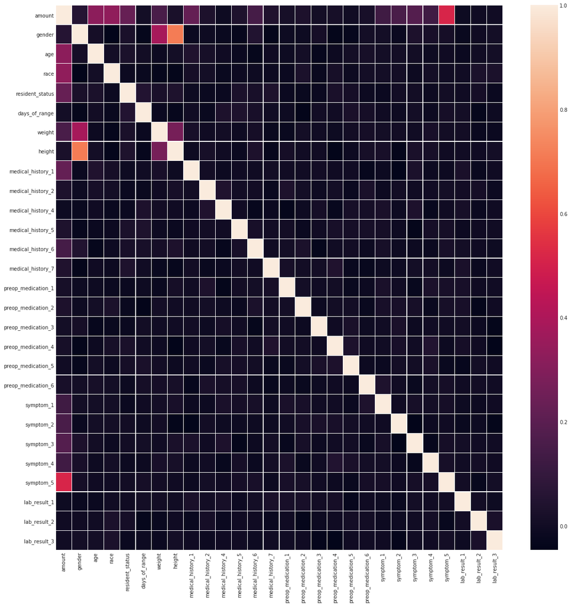

```python
fig, ax = plt.subplots(figsize=(20,20))
# plot the heatmap
sns.heatmap(corr,
        xticklabels=corr.columns,
        yticklabels=corr.columns,linewidths=.20, ax=ax)
```

### From the above heatmap we can find "age","race","resident_status","medical_history_1","symptom_3","symptom_5" have higher correlations with patients' cost of care while other features such as "gender" and lab results have very few correlations with cost of care.

### (2). Visualizing some features to verify assumptions

#### Visualize total bill amount distribution

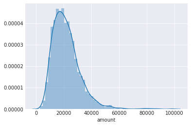

```python
sns.distplot(patient_data["amount"])
```

```python
sms.DescrStatsW(patient_data["amount"]).tconfint_mean()
```

```
(21522.21868185382, 22205.297373900434)
```

#### Relationship between gender and bill amount

```python
female_bill = patient_data[patient_data["gender"] == 0]
female_total_bill = sum(female_bill["amount"])
female_mean_bill = female_total_bill/len(female_bill["amount"])
male_bill = patient_data[patient_data["gender"] == 1]
male_total_bill = sum(male_bill["amount"])
male_mean_bill = male_total_bill/len(male_bill["amount"])
```

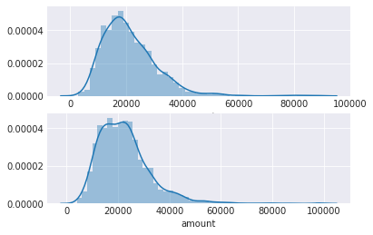

```python
fig = plt.figure()
ax1 = fig.add_subplot(211)
ax2 = fig.add_subplot(212)
sns.distplot(female_bill["amount"],ax = ax1)
sns.distplot(male_bill["amount"],ax = ax2)
```

```
 [Text(-1.09904,0.0459756,'Female_mean_bill'),
  Text(1.09904,-0.0459757,'Male_mean_bill')],
 [Text(-0.599476,0.0250776,'48.7%'), Text(0.599476,-0.0250777,'51.3%')])
```

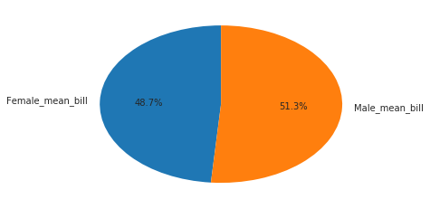

```python
plt.pie([female_mean_bill,male_mean_bill],labels=['Female_mean_bill','Male_mean_bill'],startangle=90,autopct='%1.1f%%')
```

### From the pdf we find the bill amount distribution is similar no matter which gender is. From the pie we can also find mean bill amount is nearly the same so gender has no influence in the cost of care.

#### Relations between age and cost of care

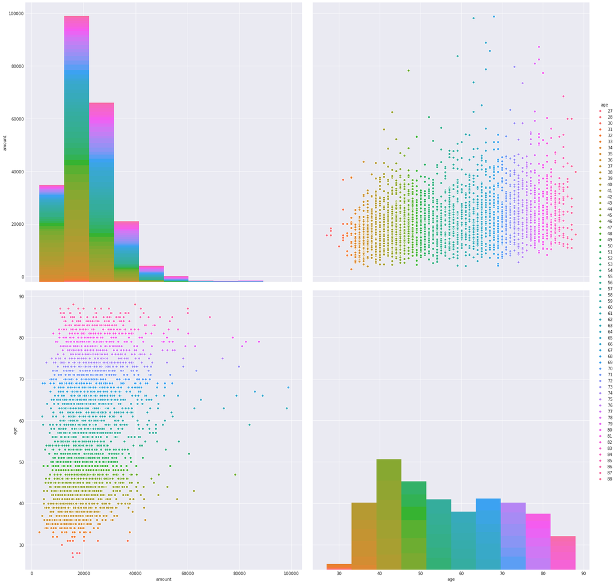

```python
age_data = patient_data[["amount","age"]]
sns.set_style("darkgrid")
sns.pairplot(age_data, hue='age', size=10)
```

### From the pairplot of seaborn we can find that most patients' bill amount is below 40000, but when the age is larger than 35, there is a trend of increasing bill amount and patients whose ages are ranging between 60-80 have highest frequencies of paying very high bill amount. This means patients can have very high risk of having serious diseases.

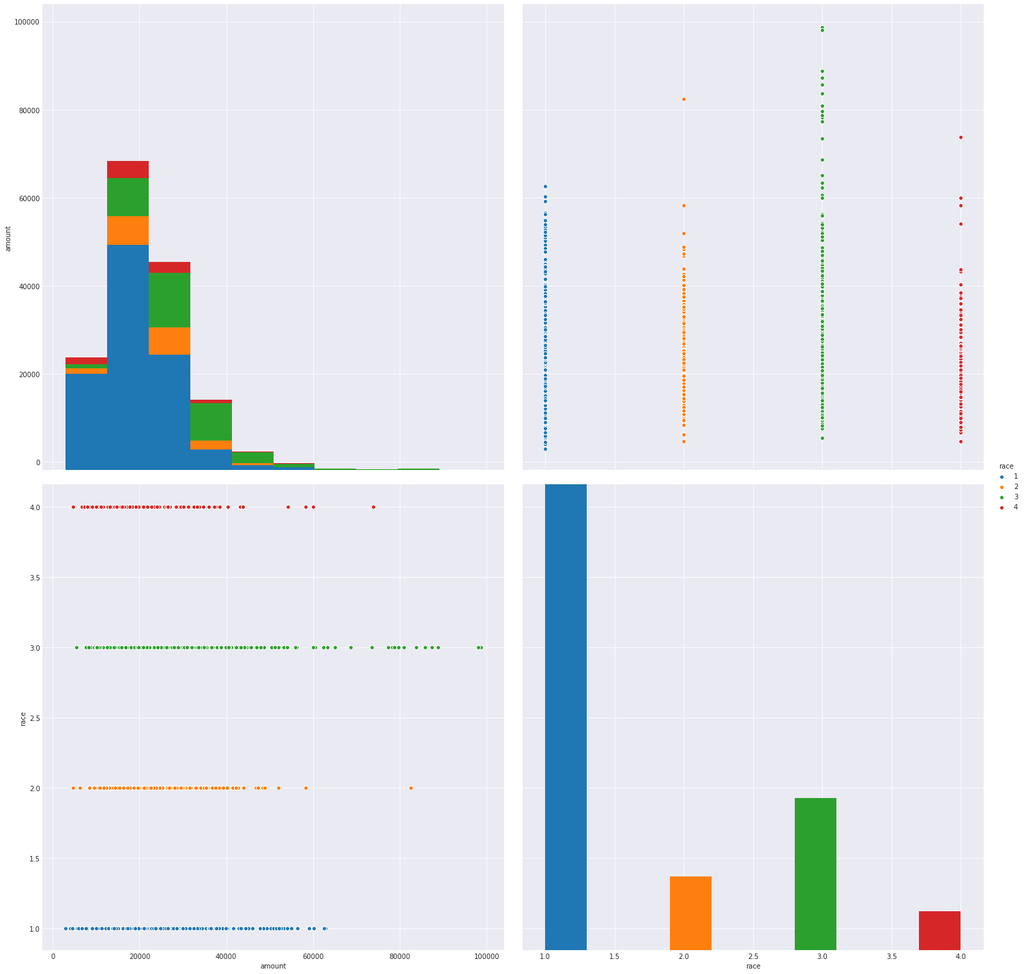

```python
race_data = patient_data[["amount","race"]]
sns.set_style("darkgrid")
sns.pairplot(race_data, hue='race', size=10)
```

```
 [Text(-0.658362,0.881226,'Chinese_mean_bill'),
  Text(-0.961576,-0.534201,'Indian_mean_bill'),
  Text(0.726059,-0.82634,'Malay_mean_bill'),
  Text(0.721475,0.830345,'Others_mean_bill')],
 [Text(-0.359107,0.480669,'20.4%'),
  Text(-0.524496,-0.291382,'25.3%'),
  Text(0.396032,-0.450731,'31.5%'),
  Text(0.393532,0.452916,'22.8%')])
```

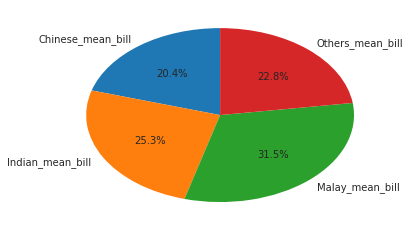

```python
Chinese_mean_bill= sum((race_data[race_data["race"] == 1])["amount"])/len(race_data[race_data["race"] == 1])
Indian_mean_bill= sum((race_data[race_data["race"] == 2])["amount"])/len(race_data[race_data["race"] == 2])
Malay_mean_bill= sum((race_data[race_data["race"] == 3])["amount"])/len(race_data[race_data["race"] == 3])
Others_mean_bill= sum((race_data[race_data["race"] == 4])["amount"])/len(race_data[race_data["race"] == 4])
plt.pie([Chinese_mean_bill,Indian_mean_bill,Malay_mean_bill,Others_mean_bill],labels=['Chinese_mean_bill','Indian_mean_bill','Malay_mean_bill','Others_mean_bill'],startangle=90,autopct='%1.1f%%')
```

### Chinese=1,Indian=2,Malay=3,Others=4.From the picture we can see that Most patients in each race paid bills ranging from 0 to 60000. Though Chinese has highest frequencies of going to the hospital their total costs are not very high. While Malaysian patients have highest opportunities of paying very high medical bills.

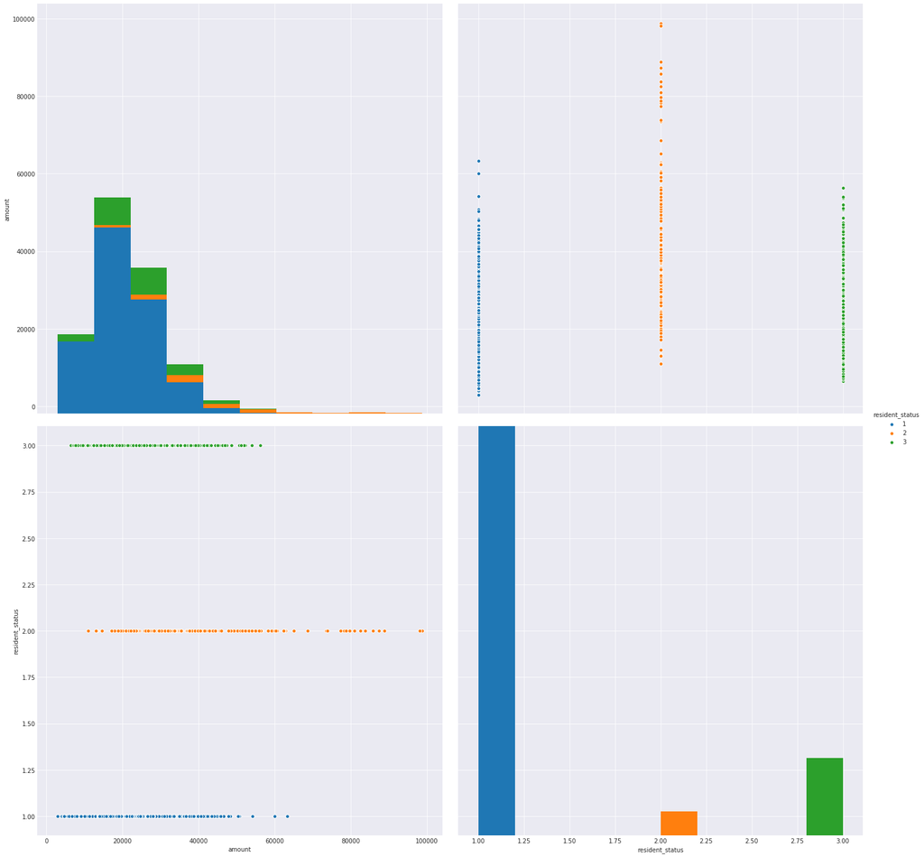

```python
resident_status_data = patient_data[["amount","resident_status"]]
sns.pairplot(resident_status_data, hue='resident_status', size=10)
```

```
 [Text(-0.738474,0.815265,'Singaporean_mean_bill'),
  Text(-0.165726,-1.08744,'Foreigner_mean_bill'),
  Text(0.852872,0.694701,'PR_mean_bill')],
 [Text(-0.402804,0.44469,'23.4%'),
  Text(-0.0903958,-0.593151,'48.3%'),
  Text(0.465203,0.378928,'28.2%')])
```

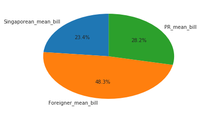

```python
Singaporean_mean_bill= sum((resident_status_data[resident_status_data["resident_status"] == 1])["amount"])/len(resident_status_data[resident_status_data["resident_status"] == 1])
Foreigner_mean_bill= sum((resident_status_data[resident_status_data["resident_status"] == 2])["amount"])/len(resident_status_data[resident_status_data["resident_status"] == 2])
PR_mean_bill= sum((resident_status_data[resident_status_data["resident_status"] == 3])["amount"])/len(resident_status_data[resident_status_data["resident_status"] == 3])
plt.pie([Singaporean_mean_bill,Foreigner_mean_bill,PR_mean_bill],labels=['Singaporean_mean_bill','Foreigner_mean_bill','PR_mean_bill'],startangle=90,autopct='%1.1f%%')
```

#### Relations between symptom_5 and cost of care

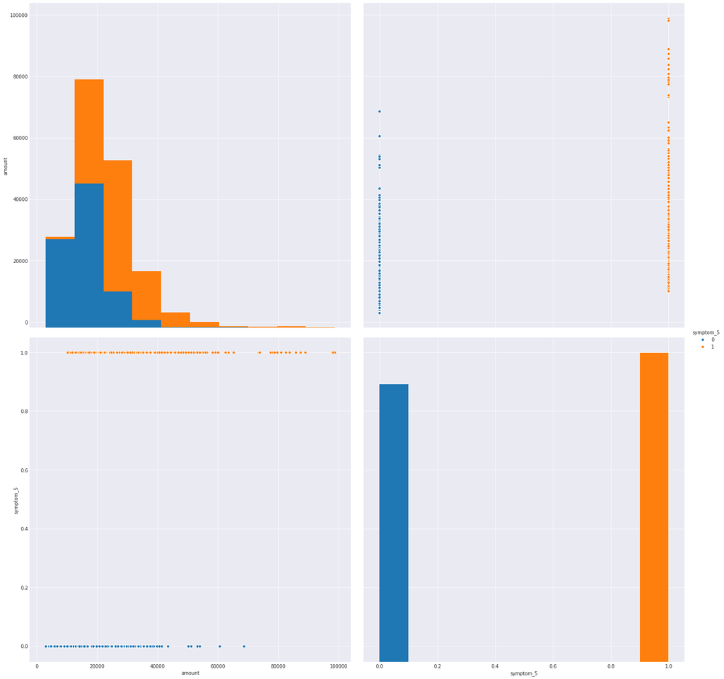

```python
symptom_5_data = patient_data[["amount","symptom_5"]]
sns.pairplot(symptom_5_data, hue='symptom_5', size=10)
```

### Though we do not know what symptom_5 is, but from the figure we can see that if symptom_5 = 1 then the patients may need to pay much higher bill amounts than those who do not have symptom_5.

## 6. Predict cost of care for new patients using regression models

### Separate original dataset to 3000 train data and 400 test data.

```python
features = ['gender','age','race','resident_status','days_of_range','weight','height','medical_history_1','medical_history_2','medical_history_3','medical_history_4','medical_history_5','medical_history_6','medical_history_7','preop_medication_1','preop_medication_2','preop_medication_3','preop_medication_4','preop_medication_5','preop_medication_6','symptom_1','symptom_2','symptom_3','symptom_4','symptom_5','lab_result_1','lab_result_2','lab_result_3']
#features = ['gender','age','race','resident_status','days_of_range','weight','height','medical_history','preop_medication','symptom_1','symptom_2','symptom_3','symptom_4','symptom_5','lab_result_1','lab_result_2','lab_result_3']
reg_data = patient_data.loc[:3000, features].values
reg_target = patient_data.loc[:3000, ["amount"]].values.ravel()
test_data = patient_data.loc[3000:, features].values
test_target = patient_data.loc[3000:, ["amount"]].values.ravel()
```

### (1). Lasso regression model

### Calculate best alpha coefficient using cross validation.

```python
lassocv = LassoCV()
lassocv.fit(reg_data, reg_target)
alpha = lassocv.alpha_
alpha
```

```
47.89084918558477
```

### Predict cost of care for 400 test data.

```python
lasso = Lasso(alpha=alpha)
test_actual_label = lasso.fit(reg_data, reg_target).predict(test_data)
train_actual_label = lasso.fit(reg_data, reg_target).predict(reg_data)
test_actual_label[:10]
```

```
array([20325.247223  , 33020.68025361, 19019.28395197, 11441.21468833,
       21672.32447034, 30469.07095205, 28108.21145087, 24575.64150398,
       30316.8627528 , 11390.81145819])
```

```python
test_target[:10]
```

```
array([19874.55192624, 33039.08967896, 18798.05368199,  9565.67074361,
       32477.03734949, 28286.34249719, 25935.27267086, 23328.15894777,
       28314.38182051, 11758.30495075])
```

```python
r2_score_lasso_train = r2_score(reg_target, train_actual_label)
r2_score_lasso_train
```

```
0.7191143205658292
```

```python
r2_score_lasso_test = r2_score(test_target, test_actual_label)
r2_score_lasso_test
```

```
0.7109589247734083
```

### (2). Linear regression model

```python
lm = linear_model.LinearRegression()
model = lm.fit(reg_data,reg_target)
```

```python
test_actual_label = lm.predict(test_data)
train_actual_label = lm.predict(reg_data)
```

```python
r2_score_linear_train = r2_score(reg_target, train_actual_label)
r2_score_linear_train
```

```
0.721161436465753
```

```python
r2_score_linear_test = r2_score(test_target, test_actual_label)
r2_score_linear_test
```

```
0.7105981923181628
```

### These regression models can help us predict new cost of care by inputing new patients' features and they can be applied to many fields such as insurance and medical consulting industry. As when we know a patient's personal information we can evaluate their potential cost in health care and insurance company can calculate their risks of selling insurance to those patients. Also those who want to sell special medicine or health equipments can have a better population target.